# 2 Tablas de Mortalidad

Author

Brayan Cubides

```r
# Limpieza del entorno
rm(list = ls(all = TRUE))
```

# 3 Distribuciones de Sobrevivencia

## 3.1 Densidad Weibull

### 3.1.1 Funciones para X

Primero se definen los parámetros estimados para la densidad Weibull y luego se construyen las funciones de densidad, sobrevivencia y distribución.

```r
# Parámetros estimados de la densidad Weibull
a <- 5.958716
b <- 78.82047

# Función de densidad de X, f(x)
fx <- function(x) {
  (a / b) * (x / b)^(a - 1) * exp(- (x / b)^a)
}

# Verificación de la densidad integrando f(x) de 0 a infinito y de 0 a w
integrate(fx, lower = 0, upper = Inf)
```

```
1 with absolute error < 3.4e-06
```

```r
w <- 120
integrate(fx, lower = 0, upper = w)
```

```
0.9999952 with absolute error < 4.4e-08
```

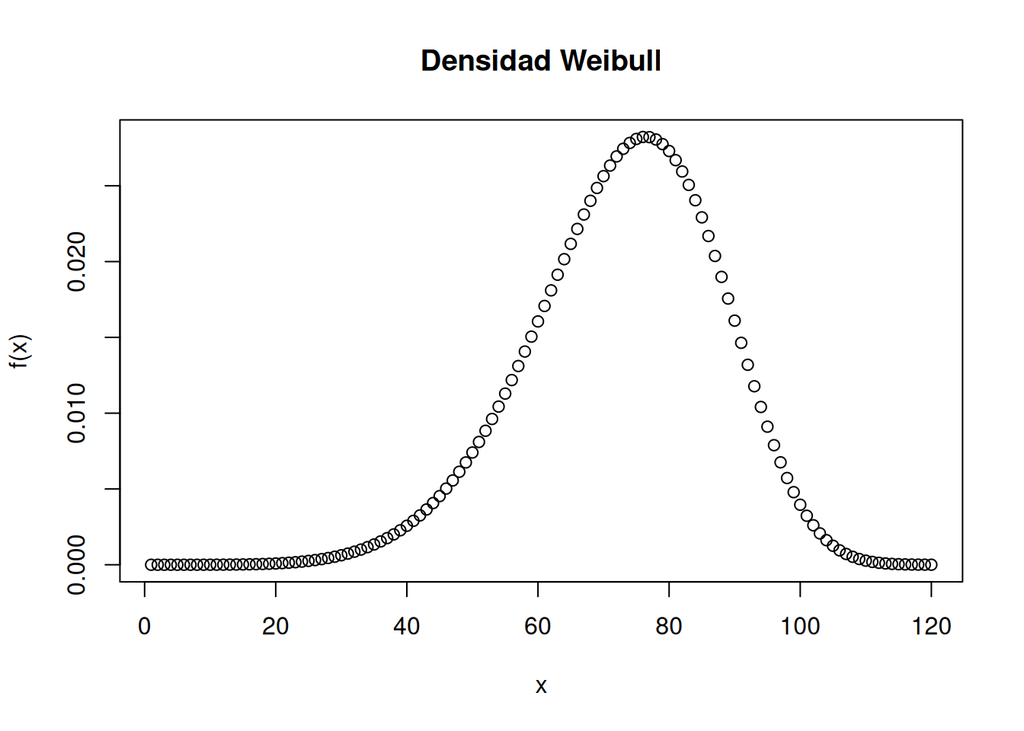

```r
# Gráfica de la densidad Weibull para x = 1,2,...,w
plot(fx(1:w), main = "Densidad Weibull", xlab = "x", ylab = "f(x)")
```

# 4 Distribución Weibull

Para una variable aleatoria (X) que sigue una distribución Weibull con parámetros (a) (forma) y (b) (escala), las expresiones relevantes son las siguientes:

## 4.1 Función de Densidad (PDF)

La densidad se expresa como:

$$f(x) = \frac{a}{b}\left(\frac{x}{b}\right)^{a-1}\exp\left[-\left(\frac{x}{b}\right)^a\right],\quad x > 0.$$

## 4.2 Función de Distribución Acumulada (CDF)

La función de distribución acumulada se define mediante la integral de la densidad:

$$F(x) = \int_0^x f(t)\,dt = \int_0^x \frac{a}{b}\left(\frac{t}{b}\right)^{a-1}\exp\left[-\left(\frac{t}{b}\right)^a\right] dt.$$

Realizando el cambio de variable

$$u = \left(\frac{t}{b}\right)^a,\quad dt = \frac{b}{a}\, u^{\frac{1}{a}-1}\,du,$$

la integral se transforma en:

$$F(x) = \int_{0}^{\left(\frac{x}{b}\right)^a}\exp(-u)\,du = 1 - \exp\left[-\left(\frac{x}{b}\right)^a\right].$$

## 4.3 Función de Supervivencia

La función de supervivencia (o función de confiabilidad) es:

$$S(x) = 1 - F(x) = \exp\left[-\left(\frac{x}{b}\right)^a\right].$$

## 4.4 Función de Riesgo (Hazard)

La función de riesgo se define como la razón entre la densidad y la función de supervivencia:

$$h(x) = \frac{f(x)}{S(x)} = \frac{\frac{a}{b}\left(\frac{x}{b}\right)^{a-1}\exp\left[-\left(\frac{x}{b}\right)^a\right]}{\exp\left[-\left(\frac{x}{b}\right)^a\right]} = \frac{a}{b}\left(\frac{x}{b}\right)^{a-1}.$$

### 4.4.1 Función de Sobrevivencia y Distribución de X

Se definen la función de sobrevivencia y, a partir de ella, la función de distribución.

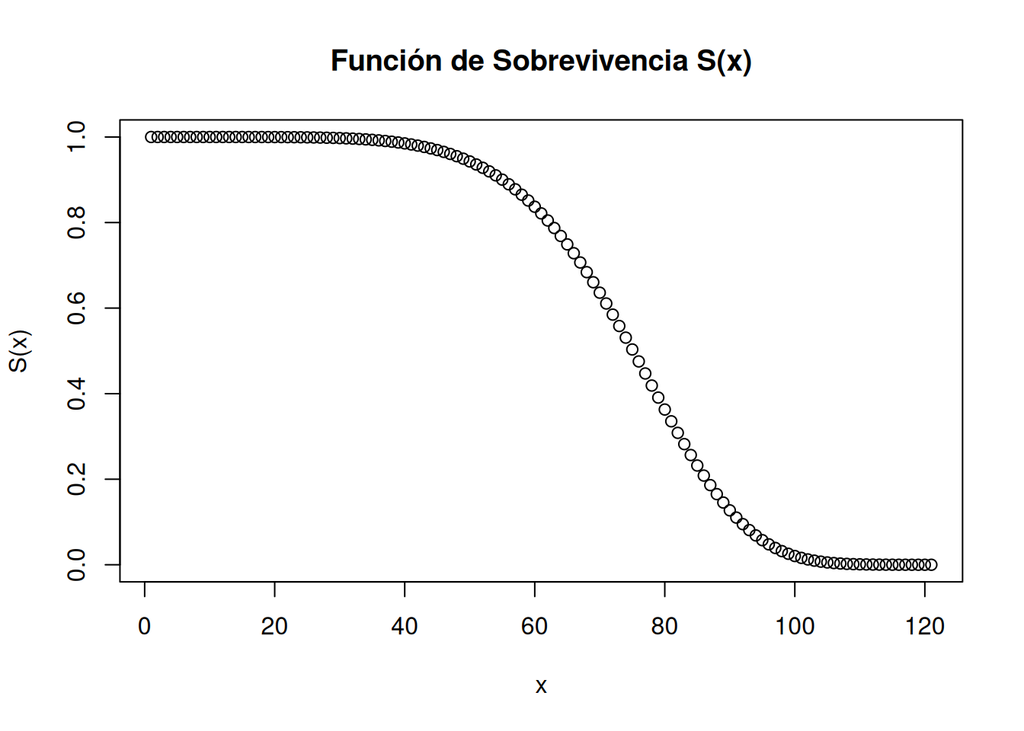

```r
# Función de sobrevivencia de X, S(x)
Sx <- function(x) {
  exp(-(x / b)^a)
}

# Gráfica de la función de sobrevivencia
plot(Sx(0:w), main = "Función de Sobrevivencia S(x)", xlab = "x", ylab = "S(x)")
```

```r
Sx(0); Sx(w)
```

```
[1] 1
```

```
[1] 4.841952e-06
```

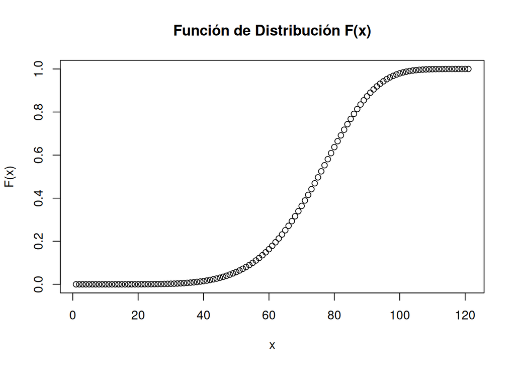

```r
# Función de distribución de X, F(x) = 1 - S(x)
Fx <- function(x) {
  1 - Sx(x)
}

# Gráfica de la función de distribución
plot(Fx(0:w), main = "Función de Distribución F(x)", xlab = "x", ylab = "F(x)")
```

```r
Fx(0); Fx(w)
```

```
[1] 0
```

```
[1] 0.9999952
```

## 4.5 Funciones para T: Tiempo futuro de vida de (x)

Ahora se consideran las funciones condicionales de sobrevivencia y fallar para un individuo de edad x, junto con la función de riesgo y la densidad de T.

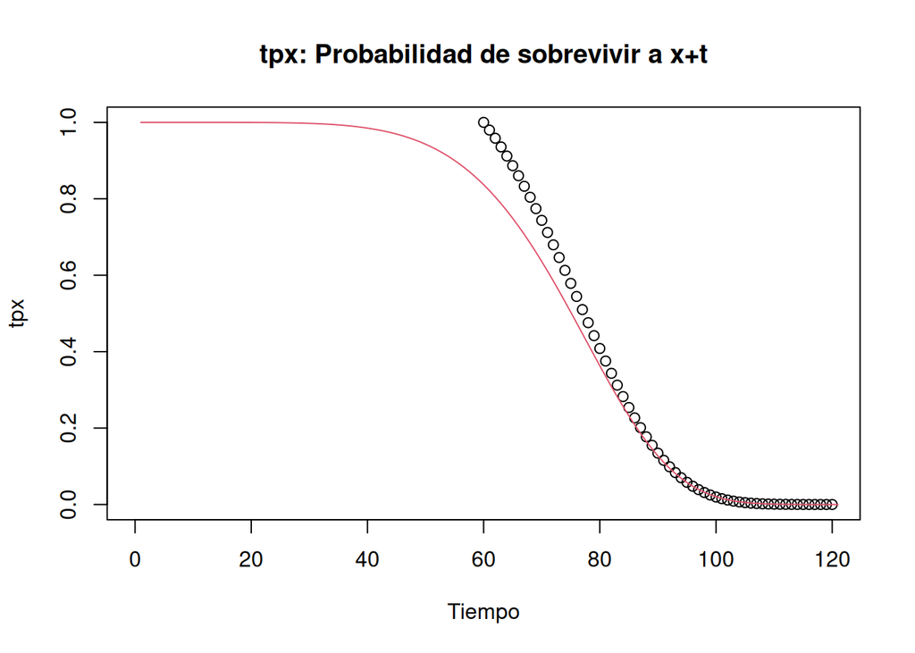

```r
# Edad inicial para el análisis
x <- 60

# tpx: Probabilidad condicional de sobrevivir a "x+t" dado que se sobrevive a "x"
tpx <- function(x, t) {
  Sx(x + t) / Sx(x)
}

# Gráfica de tpx
plot(c(x:w), tpx(x, 0:(w - x)), main = "tpx: Probabilidad de sobrevivir a x+t",
     xlab = "Tiempo", ylab = "tpx", xlim = c(0, w))
lines(Sx(0:w), col = 2)
```

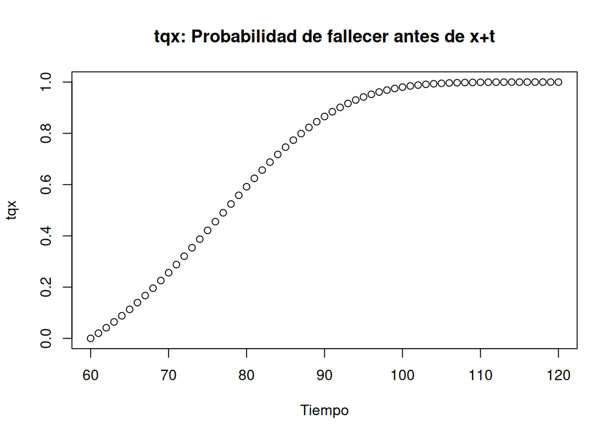

```r
# tqx: Probabilidad condicional de fallar antes de "x+t" dado que se sobrevive a "x"
tqx <- function(x, t) {
  (Sx(x) - Sx(x + t)) / Sx(x)
}

# Gráfica de tqx
plot(c(x:w), tqx(x, 0:(w - x)), main = "tqx: Probabilidad de fallecer antes de x+t",
     xlab = "Tiempo", ylab = "tqx")
```

```r
# Función de riesgo Mux1 y su versión simplificada Mux
Mux1 <- function(x) {
  fx(x) / Sx(x)
}

Mux <- function(x) {
  (a / b) * (x / b)^(a - 1)
}

Mux1(x); Mux(x)
```

```
[1] 0.01954189
```

```
[1] 0.01954189
```

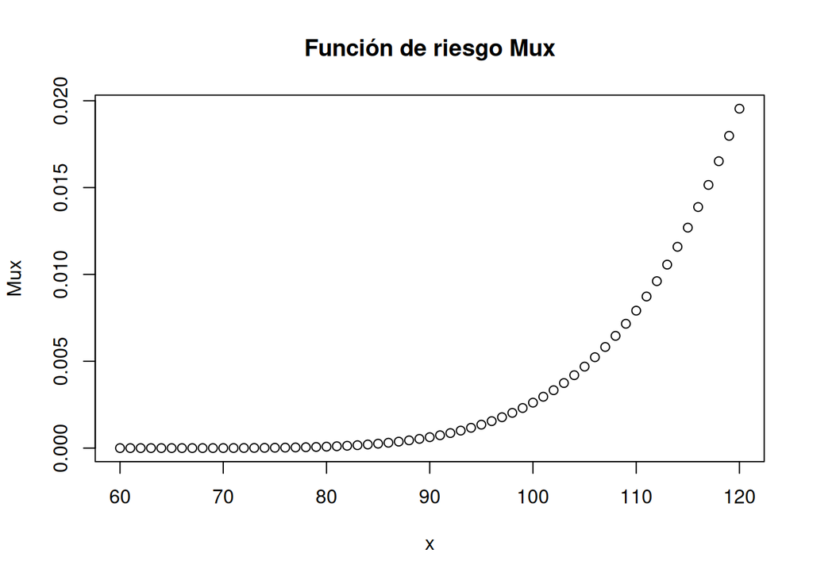

```r
plot(c(x:w), Mux(0:(w - x)), main = "Función de riesgo Mux", xlab = "x", ylab = "Mux")
```

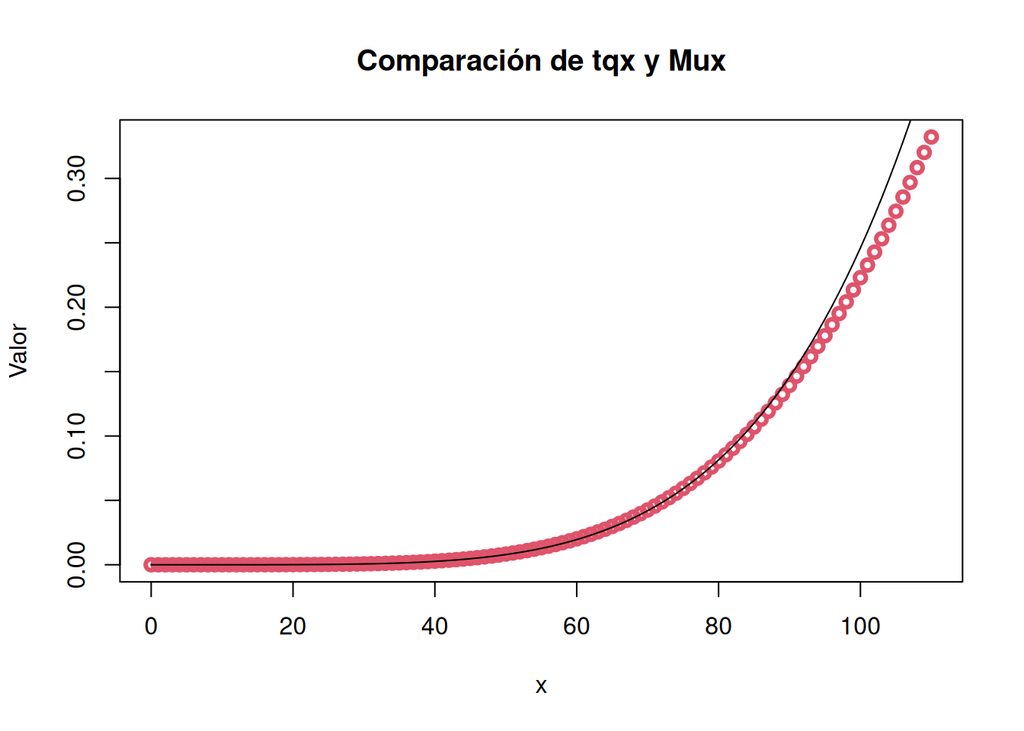

```r
# Comparación de Mu con tqx
plot(c(0:110), tqx(0:110, 1), col = 2, lwd = 3,
     main = "Comparación de tqx y Mux",
     xlab = "x", ylab = "Valor")
lines(c(0:110), Mux(0:110))
```

```r
# Función de densidad de T, f(t)
ft <- function(t) {
  tpx(x, t) * Mux(x + t)
}

integrate(ft, lower = 0, upper = Inf)
```

```
1 with absolute error < 2.6e-06
```

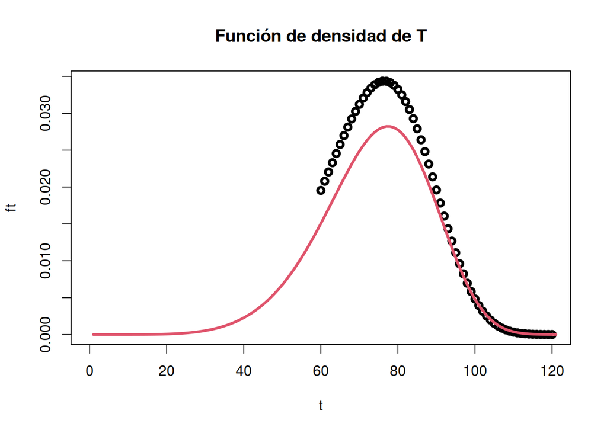

```r
plot(c(x:w), ft(0:(w - x)), xlim = c(0, w), lwd = 3,
     main = "Función de densidad de T", xlab = "t", ylab = "ft")
lines(fx(0:w), col = 2, lwd = 3)
```

# 5 Taller

## 5.1 1) Recién nacidos

### 5.1.1 a) Calcular la probabilidad de que un recién nacido muera entre 60 y 60.0833

La probabilidad es la diferencia en la función de distribución para un recién nacido (edad 0):

```r
p1a1 <- Fx(60.0833) - Fx(60)
p1a2 <- Sx(60) - Sx(60.0833)
p1a1; p1a2
```

```
[1] 0.001340586
```

```
[1] 0.001340586
```

### 5.1.2 b) Aproximar la probabilidad del punto (a) con base en el uso directo de f(x)

Se utiliza la aproximación lineal usando la densidad en el inicio del intervalo:

```r
delta <- 1/12
p1b <- fx(60) * delta
p1b
```

```
[1] 0.001337605
```

### 5.1.3 c) Calcular la probabilidad de que un recién nacido muera entre 80 y 80.0833

De forma similar, se calcula la diferencia en la función de distribución:

```r
p1c1 <- Fx(80.0833) - Fx(80)
p1c2 <- Sx(80) - Sx(80.0833)
p1c1; p1c2
```

```
[1] 0.00227147
```

```
[1] 0.00227147
```

## 5.2 2) Calcular la probabilidad de que (60) muera entre 60 y 60.0833.

Para un individuo que ya tiene 60, las probabilidades se condicionan a haber sobrevivido hasta 60.

### 5.2.1 a) Usando f(x)

La probabilidad condicional es:

$$P(60 < X \le 60.0833 \mid X > 60)= \frac{F(60.0833) - F(60)}{S(60)}= \frac{\int_{60}^{60.0833} f(x)\,dx}{\int_{60}^{\infty} f(x)\,dx}$$

```r
# Usando diferencia de la función de distribución
p2a1 <- (Fx(60.0833) - Fx(60)) / Sx(60)

# Alternativamente: integrar la densidad
numerador <- integrate(fx, lower = 60, upper = 60.0833)$value
denominador <- integrate(fx, lower = 60, upper = Inf)$value
p2a_alt <- numerador / denominador

p2a1; p2a_alt
```

```
[1] 0.001632119
```

```
[1] 0.001632119
```

### 5.2.2 b) Usando (f_T(t))

La densidad del tiempo futuro de vida (T) para un individuo de 60 años está dada por:

$$f_T(t) = tpx(60, t) \cdot \mu(60 + t)$$

Entonces, la probabilidad de que muera entre los 60 y 60.0833 años, es decir, que es:

$$P(0 < T \le 0.0833) = \int_0^{0.0833} f_T(t)\,dt$$

```r
# Cálculo directo de la probabilidad mediante la integral de f_T(t)
p2b <- integrate(ft, lower = 0, upper = 0.0833)$value
p2b
```

```
[1] 0.001632119
```

Esta es otra forma de calcular la misma probabilidad que en el punto anterior, pero vista desde la variable aleatoria de tiempo futuro (T = X - 60).

### 5.2.3 c) Aproximar la probabilidad con base en el uso directo de $\mu(x)$

```r
p2c <- Mux(60) * 0.0833
p2c
```

```
[1] 0.001627839
```

### 5.2.4 d) Calcular la probabilidad de que (80) muera entre 80 y 80.0833

Para un individuo de 80 se tiene:

$$P(80 < X \le 80.0833 \mid X > 80) = \frac{F(80.0833)-F(80)}{S(80)}.$$

```r
p2d <- (Fx(80.0833) - Fx(80)) / Sx(80)
p2d
```

```
[1] 0.006773194
```

## 5.3 3) Calcular la probabilidad de que (60) muera entre 80 y 80.0833.

Aquí el intervalo de tiempo en la vida futura es de ( t=20 ) a ( t=20.0833 ) (ya que (80-60=20)).

### 5.3.1 a) Usando f(x)

La probabilidad condicional usando la función de distribución es:

$$P(80 < X \le 80.0833 \mid X > 60)=\frac{F(80.0833)-F(80)}{S(60)}.$$

```r
p3a <- (Fx(80.0833) - Fx(80)) / Sx(60)
p3a
```

```
[1] 0.002765441
```

### 5.3.2 b) Usando f(t)

Integramos la densidad de la vida futura (f_T(t)) en el intervalo (t [20,20.0833]):

```r
p3b <- integrate(ft, lower = 20, upper = 20.0833)$value
p3b
```

```
[1] 0.002765441
```

```r
p3c <- Mux(80) * 0.0833
p3c
```

```
[1] 0.006778712
```

## 5.4 4) Esperanza de vida

La esperanza de vida para un individuo de edad (x) es:

$$e_x = \frac{1}{S(x)}\int_x^\infty S(t)\,dt.$$

### 5.4.1 a) Calcular la esperanza de vida para (0), (20) y (60)

```r
e0 <- integrate(Sx, lower = 0, upper = Inf)$value
e20 <- integrate(Sx, lower = 20, upper = Inf)$value / Sx(20)
e60 <- integrate(Sx, lower = 60, upper = Inf)$value / Sx(60)
e0; e20; e60
```

```
[1] 73.0953
```

```
[1] 53.11111
```

```
[1] 17.90395
```

### 5.4.2 b) Calcular la esperanza de vida de (60) en un horizonte de 10 años

Aquí se calcula la esperanza de vida limitada a 10 años. Se usa:

$$e_{60}^{(10)} = \int_{0}^{10} t\,f_T(t)\,dt + 10\cdot tpx(60,10),$$

donde (tpx(60,10) = Sx(70)/Sx(60)) es la probabilidad de sobrevivir a 10 años.

```r
e60_10 <- integrate(function(t) t * ft(t), lower = 0, upper = 10)$value + 10 * tpx(60, 10)
e60_10
```

```
[1] 8.816834
```

## 5.5 5) Cálculo usando Supuestos Alternativos

Calcular la probabilidad del punto (2) - Pr(que (60) muera entre 60 y 60.0833) - con base en los supuestos de los siguientes 3 puntos, que son supuestos alternativos para aproximar la probabilidad usando la función de riesgo, los siguientes:

### 5.5.1 a) Distribución uniforme de muertes

```r
p5a <- ((Mux(60) + Mux(60.0833)) / 2) * 0.0833
p5a
```

```
[1] 0.001633458
```

### 5.5.2 b) Supuesto Balducci

Bajo Balducci se aproxima la probabilidad como:

$$q \approx \frac{\mu(60)\delta}{1 + \mu(60)\delta/2}.$$

```r
p5b <- (Mux(60) * 0.0833) / (1 + (Mux(60) * 0.0833) / 2)
p5b
```

```
[1] 0.001626515
```

### 5.5.3 c) Fuerza constante de mortalidad

Suponiendo una fuerza de mortalidad constante en el intervalo, la probabilidad es:

$$q \approx 1 - \exp\bigl(-\mu(60)\cdot 0.0833\bigr).$$

```r
p5c <- 1 - exp(-Mux(60) * 0.0833)
p5c
```

```
[1] 0.001626515
```

# 6 Tabla de Mortalidad

```r
# Función para generar tabla de mortalidad
CrearTablaMortalidad <- function(w, l0 = 100000, fx, Sx, tpx, tqx) {
  x <- 1:w
  fx_v <- fx(x)
  Sx_v <- Sx(x)
  Fx_v <- 1 - Sx_v
  px_v <- tpx(x, 1)
  qx_v <- tqx(x, 1)
  lx <- numeric(w)
  lx[1] <- l0
  for (i in 2:w) {
    lx[i] <- lx[i - 1] * px_v[i - 1]
  }
  dx <- lx * qx_v
  data.frame(
    edad = x, fx = fx_v, Fx = Fx_v, px = px_v, qx = qx_v, Sx = round(Sx_v,6), lx = round(lx), dx = round(dx)
  )
}

# Generar la tabla usando Weibull y cohorte inicial de 100000
tabla <- CrearTablaMortalidad(
  w = 120, l0 = 100000,
  fx = fx, Sx = Sx, tpx = tpx, tqx = tqx
)

# Mostrar la tabla
print(tabla)
```

```
    edad           fx           Fx        px           qx       Sx     lx   dx
1      1 2.975907e-11 4.994227e-12 1.0000000 3.056183e-10 1.000000 100000    0
2      2 9.254259e-10 3.106125e-10 1.0000000 3.168727e-09 1.000000 100000    0
3      3 6.910798e-09 3.479339e-09 1.0000000 1.583906e-08 1.000000 100000    0
4      4 2.877822e-08 1.931840e-08 0.9999999 5.369969e-08 1.000000 100000    0
5      5 8.701881e-08 7.301809e-08 0.9999999 1.433778e-07 1.000000 100000    0
6      6 2.149069e-07 2.163959e-07 0.9999997 3.258121e-07 1.000000 100000    0
7      7 4.615517e-07 5.422079e-07 0.9999993 6.592909e-07 0.999999 100000    0
8      8 8.949230e-07 1.201498e-06 0.9999988 1.222468e-06 0.999999 100000    0
9      9 1.604856e-06 2.423965e-06 0.9999979 2.117357e-06 0.999998 100000    0
10    10 2.706035e-06 4.541316e-06 0.9999965 3.472310e-06 0.999995 100000    0
11    11 4.340967e-06 8.013611e-06 0.9999946 5.444986e-06 0.999992  99999    1
12    12 6.682929e-06 1.345855e-05 0.9999918 8.225293e-06 0.999987  99999    1
13    13 9.938909e-06 2.168374e-05 0.9999880 1.203834e-05 0.999978  99998    1
14    14 1.435252e-05 3.372181e-05 0.9999829 1.714733e-05 0.999966  99997    2
```

[output cut: 106 more lines]